# Merging Open Health Facility Data Sets: Part 1

Anelda van der Walt

16 April 2020

[figure not shown]

** *Please observe individual dataset licensing if you would like to use the original datasets*

# Background

## `afrimapr` and `afrihealthsites`

Early in March 2020 the [*afrimapr* team](http://afrimapr.org) started looking into mapping, comparing, and combining open health facility data sets to enable better access for decision makers in Africa during and after the COVID-19 pandemic. The [`afrihealthsites` package](http://afrimapr.org/code) currently allows one to compare two existing continental open data sets - one developed by the Kenya Medical Research Institute (KEMRI) in collaboration with the WHO, the second a global crowd sourced open health facilities mapping project - healthsites.io. `afrihealthsites` is under active development and we aim to get it out to potential users very early in the development cycle to allow for continuous input that can shape its functionality.

## South Africa: A case study

In South Africa the [Data Science for Social Impact](https://dsfsi.github.io/) group created an open [COVID-19 dataset and dashboard](https://arxiv.org/abs/2004.04813) to assist with local efforts. The group recruited volunteers to assist with the the collation of information about hospital resources in South Africa and I thought was a great practical use-case for the kind of tools we had in mind to build within *afrimapr*. For more information about the challenges associated with building a comprehensive list of health facilities for South Africa see [this Github issue](https://github.com/dsfsi/covid19za/issues/115). During our conversations about developing a list of hospitals with various attributes such as address, website, contact details, services available, and corona-readiness, we realised this wasn’t going to be a trivial exercise.

## Master Facility Lists

These challenges are experienced in every country when health facility lists from various stakeholders are combined to create, what is called, a Master Facility List (MFL). According to the [Master Facility List (MFL) Resource Pack](https://www.who.int/healthinfo/MFL_Resource_Package_Jan2018.pdf?ua=1) developed in 2018 by the WHO/USAID, the MFL is a complete, up-to-date, authoritative listing of the health facilities in a particular country. The article by [Maina et al (2019)](https://www.ncbi.nlm.nih.gov/pmc/articles/PMC6658526/) describes their experience in collating a MFL for Kenya and subsequently assisting other countries to develop in-house MFLs and finally the continental health facility list.

A MFL typically contains information about health facilities including:

- data to accurately identify a facility (e.g. name, unique identifier, location, contact information);
- administrative data (e.g. facility type, ownership, operational status) and
- information about the service capacity (e.g. types of services offered, number of beds).

According to the WHO, a MFL should be updated regularly (at least every two years), should be verified, and must be accessible to stakeholders. The [Master Facility List (MFL) Resource Pack](https://www.who.int/healthinfo/MFL_Resource_Package_Jan2018.pdf?ua=1) provides further guidance on the development or strengthening of a Master Facility List.

Countries can benefit tremendously from having a high quality, up-to-date MFL in the following ways:

- it can create efficiencies by having to maintain a single list rather than maintaining several lists and continuously facing the challenge of integration;
- it facilitates information exchange across different health data systems;
- it provides metadata needed by other information systems;
- it can facilitate planning and management and
- it can support case management of patients.

A quick Google search lead to openly available MFLs for at least the following African countries:

- [Malawi](https://github.com/BaobabHealthTrust/master-facility-list)
- [Kenya](http://kmhfl.health.go.ke/#/home)
- [Namibia](https://mfl.mhss.gov.na/)
- [Nigeria](https://hfr.health.gov.ng/download/facilities)
- [Tanzania](http://hfrportal.moh.go.tz/)
- [Uganda](https://health.go.ug/sites/default/files/Signed%20n%20final%20mfl.pdf) - in PDF format

# Creating a master table which will be populated from the various datasets

The ultimate aim of this project is to work through the process of collating the best possible facility list for South Africa by combining various openly available resources. We acknowledge that this cannot be called the Master Facility List as we will only work with openly available data sets and do not have access to all information available to the Department of Health (beyond what is published in the Data Dictionary). We want to understand the process and see where [*afrimapr*](http://afrimapr.org) can aid by developing building blocks to facilitate similar processes and complimentary data analysis workflows.

We’ll create a master table that contains columns as follows:

- *country_name*: The country name. In this case it will be South Africa
- *country_iso3c*: The country [3-letter iso code](https://en.wikipedia.org/wiki/ISO_3166-1_alpha-3)
- *admin1_name***: Province name but can be state or other administrative division level 1 for other countries
- *admin1_abb*: Abbreviation of the province/state name
- *admin2_name*: Administrative division level 2 name - in SA that is the district municipality
- *admin2_abb*: Abbreviation of the DM name
- *admin3_name*: Administrative level 3 name - in SA that is the local municipality
- *admin3_abb*: Administrative level 3 abbreviation
- *admin4_name*: Administrative level 4 name - in SA that is the ward
- *city_name*: Name of the city or town
- *lat*: The facility’s latitude coordinates
- *long*: The facility’s longitude coordinates
- *type*: The type of facility (e.g. clinic, hospital, etc)
- *class*: Private or public
- *fac_name*: Name of the facility
- *fac_id*: Unique facility identifier
- *osm_id*: A unique facility identifier in Open Streetmaps
- *osm_type*: Open Streetmaps type of point
- *date_closed*: Date when the facility was closed
- *date_opened*: Date when the facility was opened
- *contact_person*: Contact person name for the facility
- *phys_address*: The physical address of the facility
- *post_address*: Postal address of the facility
- *web*: The website URL for the facility
- *contact_phone*: The contact number for the facility
- *contact_email*: The general contact email for the facility
- *org_owner*: The organisation that is responsible for the facility (e.g. Municipality, province, private, etc.)
- *org_rural_urban*: Is this facility located in a rural or urban region
- *services*: What services are available at the facility
- *num_beds*: Number of beds if the facility is a hospital
- *numb_surgical_beds*: Number of surgical beds if the facility is a hospital
- *numb_surgeons*: Number of surgeons if the facility is a hospital
- *numb_nurses*: Number of nurses
- *open_hours*: The operating hours of the facility
- *emergency*: Yes/No if the facility have an emergency department
- *notes*: Any free text notes available about the facility
- *wheelchair*: Is it wheelchair accessible
- *electricity*: Source of electricity
- *water*: Source of water
- *dispensing*: Can medicine be dispensed
- *completeness*: How many of these columns are populated for the facility

** *Note: Please visit the entry in Wikipedia to learn more about [different administrative divisions](https://en.wikipedia.org/wiki/List_of_administrative_divisions_by_country) in different countries.*

# Collecting open hospital data sets from the Web

A wide variety of health facility web portals and data sets are available online. Some access points do not allow for data download, for example the Department of Health’s [Primary Health Care Facilities and Services](https://www.healthestablishments.org.za/Home/Facility) page. Wikidata, the central storage for structured data of its Wikimedia sister projects, hosts a project named [Medicine/Hospitals by country/South Africa](https://www.wikidata.org/wiki/Wikidata:WikiProject_Medicine/Hospitals_by_country/South_Africa) which includes 208 facilities. Unfortunately the data for each facility is very sparsely populated.

The [District Health Barometer report data for 2017/2018](https://www.hst.org.za/publications/Pages/DHB20172018.aspx) was not considered for further analysis due to the inaccessible formatting of the tables in the spreadsheet.

[Medpages](https://www.medpages.info/sf/index.php?page=homepage), a private company, claims to be “the largest, most accurate, most up to date and most complete healthcare database available for Africa”. Their data is not available for download except with express written consent (and at a fee) as they operate on a subscription basis. At the time of writing this report Medpages had contact information for 188,024 health organisations and 239,931 healthcare professionals (and counting as this is an actively managed database).

[South African Doctors](http://doctors-hospitals-medical-cape-town-south-africa.blaauwberg.net) is an online resource maintained by a private individual. The data is not available for download.

The following potentially useful sources with downloadable data were identified.

[output not shown]

Note:

* A previous version of this report incorrectly stated that the healthsites.io data is licensed as CC-BY 4.0 and the owner/origin as Healthsites/Crowdsourcing

# Data cleaning

Most data sets required cleaning up to be able to work with in a programmatic way.

## Hospital Bed Data

### Raw data format

The data was made available in an Excel spreadsheet format with separate sheets for every province’s private and public health facilities.

[figure not shown]

Hospital Bed Data screenshot

### Raw data to tidy data

The *readme* file displayed below shows the steps taken to convert the raw Hospital Bed data set to tidy data. The data was not extracted programmatically due to the variable format of the tables in each sheet.

```
Source: https://figshare.com/articles/SURGICAL_RESOURCES_latestmarch2016_xlsx/12066711
New file: za_hospital_resources.csv
Steps to recreate:

1.  Create new file with two sheets - one for public hospital information and one for private hospital information
2.  Copy the primary table in each sheet into the relevant sheet in the new file (each province one under the other to create a single table in each sheet)
3.  Insert column for province
4.  Insert column for public/private
5.  Remove secondary phone numbers for ease of analysis
6.  Replace tel: with ‘ to keep 0 at beginning of phone numbers (some tel: has 1 space between colon and 0)
7.  Remove spaces from phone numbers for ease of comparison later on
8.  Remove coordinates for GP hospitals as it was for regions not individual hospitals
9.  Change kz Matatiele Private hospital from EC private hospitals to ec Matatiele Private hospital (Googled to confirm it is in EC)
10. Change ns Mediclinic Kimberley to NC Mediclinic Kimberley
11. Remove preceding province code from hospital names with replace ^\w\w\s
12. Remove all districts with nil private hospitals
13. Remove coordinate columns (will add later)
14. Change column headers for public hospitals:
  PROVINCE,province
  REGION,region
  GPS,[removed]
  HOSPITAL TYPE,hosp_class
  HOSPITAL,hosp_name
  USABLE BEDS,beds_usable
  APPROVED BEDS,beds_approved
  USABLE SB,beds_surgical_usable
  APP SURG BEDS,beds_surgical_approved
  SURGEONS (QUAL),surgeons_qualified
  SURGEONS (UNQUAL),sugeons_unqualified
  THEATRES,theatres
  CONTACT,hosp_contact
  TYPE,hosp_type
12. Change column headers for private hospitals
  PROVINCE,province
  GPS,[removed]
  REGION,region
  HOSPITAL TYPE,hosp_class
  HOSPITAL,hosp_name
  USABLE BEDS,beds_usable
  USE SUR BED,beds_surgical_usable
  THEATRES,theatres
  TYPE,hosp_type
13. Combine private/public data into a single spreadsheet
14. Add columns for source_date_day, source_date_month, source_date_year to keep track of when data was last updated
15. Add source column with link to original dataset in Figshare
16. Add column for source_name, source_surname
17. Add column for source_email
18. Add column for source_phone
19. Export to za_hospital_resources.csv
```

### Tidy data

| admin1_abb | admin2_name | type | fac_name | num_beds_usable | num_beds_approved | num_surgical_beds_usable | num_surgical_beds_approved | num_surgeons_qual | num_surgeons_unqual | num_theatres | contact_phone | sector | admin1_name |
| --- | --- | --- | --- | --- | --- | --- | --- | --- | --- | --- | --- | --- | --- |
| GP | Ekurhuleni | Independent | Actonville/Sunshine Hospital | 200 | NA | 5 | NA | NA | NA | 5 | NA | private | Gauteng |
| GP | Ekurhuleni | Life | Life Bedford Gardens Private Hospital | 140 | NA | 31 | NA | NA | NA | 6 | NA | private | Gauteng |
| GP | Ekurhuleni | Independent | Birchmed Surgical Centre | 21 | NA | 21 | NA | NA | NA | 3 | NA | private | Gauteng |
| GP | Ekurhuleni | Clinix | Clinix Private Hospital Vosloorus/ Botshelong-Empilweni | 104 | NA | 40 | NA | NA | NA | 3 | NA | private | Gauteng |
| GP | Ekurhuleni | Netcare | Clinton Clinic Netcare Hospital | 165 | NA | 99 | NA | NA | NA | 5 | NA | private | Gauteng |
| GP | Ekurhuleni | Life | Life Dalview Clinic Hospital | 75 | NA | 27 | NA | NA | NA | 4 | NA | private | Gauteng |

## DoH District Health Barometer Data 2016/2017

### Raw data format

The data was made available in Excel spreadsheet format with separate sheets for a variety of definitions, measurements, and summaries. The health facility list was stored in a sheet called ‘Hospitals’. District codes is available in this sheet, but we need to get the full district (or municipality) name from a sheet called ‘Seq’.

[figure not shown]

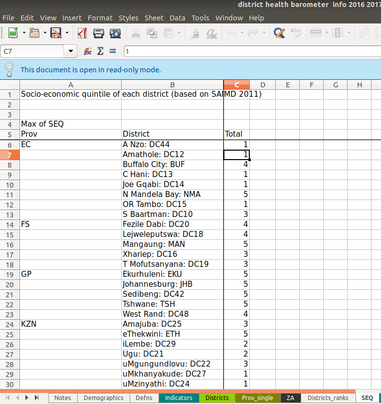

District full names for decoding

### Raw data to tidy data

The *readme* file displayed below shows the steps taken to convert the raw DoH Health Barometer hospital data set to tidy data. The data was not extracted programmatically due to the variable format of the tables in each sheet. Once data was in CSV format it was further cleaned up in [Openrefine](http://openrefine.org) with [this JSON script](https://github.com/anelda/za_open_hospital_data/blob/master/scripts/za_hospital_temp_to_refine.json). The CSV was then exported from Openrefine and imported into R for subsequent cleaning and analysis. The full steps for data cleaning are described below. The R code is available in [this file](https://github.com/anelda/merge_open_hospital_data/blob/master/reports/merge_open_hospital_data_part1.Rmd).

```
Source: File = http://www.health.gov.za/index.php/2014-03-17-09-09-38/reports/category/424-reports-2017# District HealthBarometer info 2016 2017 06 Feb 2018 (a spreadsheet)
Sheet:   ‘Hospitals’
New temp files: za_hospital_list_temp.csv, za_hospital_list_refine.csv
New final file: za_hospital_list_DoH.csv

Steps to get from Source file to New file:

1.  In sheet = ‘Hospitals’ select OrgUnitCategor = ‘All’ and Level = ‘All’ in  http://www.health.gov.za/index.php/2014-03-17-09-09-38/reports/category/424-reports-2017# District HealthBarometer info 2016 2017 06 Feb 2018 (a spreadsheet)
2.  Copy/paste table (from row 8 – 9346, column A – D)
3.  Add columns for day/month/year last updated
4.  Insert 6 February 2018 as last updated date (from file name)
5.  Add columns for source information
6.  Add columns with information about copyright ownership
7.  Export za_hospital_temp.csv for import into OpenRefine 3.2
8.  Open za_hospital_temp.csv in Openrefine 3.2
9a) Rename project to za_hospital_list_refine
9b) In undo/redo tab, select applyan za_hospital_list_temp_to_refine.json
9c) Paste contents from za_hospital_list_temp_to_refine.json and click on ‘Perform Operations’
  ** JSON script will do the following automatically
10a)  Remove rows that has provincial totals in
10b)  Fill cells down so that every cell has province, district, orgunittype
10c)  Change column header names
10d)  Remove leading province code from facility names
11. Export za_hospital_list_refine.csv from OpenRefine
12. Run za_hospital_list_refine_to_DoH.R in Rstudio
  ** R script will do the following:
13a)  Load za_hospital_refine.csv and za_hospital_district_names.csv (see readme_za_hospital_district_names.txt)
13b)  Merge the two tables in the files to create a new table with all the columns from za_hospital_list_refine.csv and a new column “district_name” from za_hospital_district_names.csv
13c)  Re-order the columns to make sense
13d) Export a new CSV file called za_hospital_list_DoH.csv
14. The final file contains the following columns:
  province  :  Province
  district_mdb  :  District code (from original source file)
  district_name : District name (from original source file)
  org_unit_type : Organisational Unit Type e.g. clinic, Community Day Centre, etc
  facility_name : Hospital/clinic etc name
  date_updated_day  :  From source file name
  date_updated_month  :  From source file name
  date_updated_year : From source file name
  source  :  URL for source file
  source_name : Organisation that provided the file (South African Dep of Health)
  copyright : Who owns the data if not in public domain or under open license
```

To clean the district names sheet for use in a join with the hospitals data the following steps were followed:

```
Source: File = http://www.health.gov.za/index.php/2014-03-17-09-09-38/reports/category/424-reports-2017# District HealthBarometer info 2016 2017 06 Feb 2018 (a spreadsheet)
Sheet:  ‘Seq’
New File: za_hospital_district_names.csv

Steps to get from Source file to New file:

1.  Copy/paste table (from row 5 – 57, column A – B)
2.  Fill province column manually
3.  Split column B on : to separate district name from district code
4.  Rename columns
5.  Export as CSV to join with za_hospital_list_refine.csv exported from OpenRefine (see readme_za_hospital_list.txt)
6.  Follow steps in readme_za_hospital_list.txt
```

To join the hospital data with the district names data, a short R script was written and is included in [this file](https://github.com/anelda/merge_open_hospital_data/blob/master/reports/merge_open_hospital_data_part1.Rmd).

### Tidy data

| admin1_abb | admin2_abb | admin2_name | type | fac_name | admin1_name |
| --- | --- | --- | --- | --- | --- |
| EC | BUF | Buffalo City | Clinic | Alphendale Clinic | Eastern Cape |
| EC | BUF | Buffalo City | Clinic | Amahleke Clinic | Eastern Cape |
| EC | BUF | Buffalo City | Clinic | Amatola TB Clinic | Eastern Cape |
| EC | BUF | Buffalo City | Clinic | Aspiranza Clinic | Eastern Cape |
| EC | BUF | Buffalo City | Clinic | Beacon Bay Clinic | Eastern Cape |
| EC | BUF | Buffalo City | Clinic | Berlin Clinic | Eastern Cape |

## HST District Health Barometer Data 2018/2019

### Raw data format

The data was made available in Excel Binary Workbook format (.xlsb) with separate sheets for a variety of definitions, measurements, and summaries. Health facility information was available from a sheet called ‘Fac_list’.

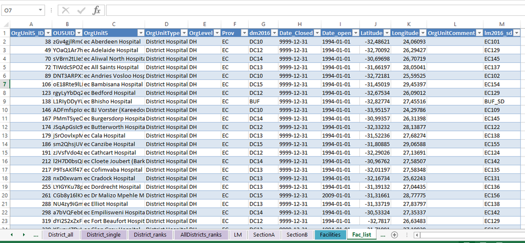

HST District Health Barometer Data screenshot

### Tidy data

Data cleaning was performed in R (the code is included in [this document](https://github.com/anelda/merge_open_hospital_data/blob/master/reports/merge_open_hospital_data_part1.Rmd)).

| fac_name | type | admin1_abb | admin2_abb | date_closed | date_opened | lat | long | notes | admin3_abb | admin1_name |
| --- | --- | --- | --- | --- | --- | --- | --- | --- | --- | --- |
| Aberdeen Hospital | District Hospital | EC | DC10 | NA | 1994-01-01 | -32.48621 | 24.06093 |  | EC101 | Eastern Cape |
| Adelaide Hospital | District Hospital | EC | DC12 | NA | 1994-01-01 | -32.70092 | 26.29427 |  | EC129 | Eastern Cape |
| Aliwal North Hospital | District Hospital | EC | DC14 | NA | 1994-01-01 | -30.69698 | 26.70719 |  | EC145 | Eastern Cape |
| All Saints Hospital | District Hospital | EC | DC13 | NA | 1994-01-01 | -31.66197 | 28.05041 |  | EC137 | Eastern Cape |
| Andries Vosloo Hospital | District Hospital | EC | DC10 | NA | 1994-01-01 | -32.72181 | 25.59525 |  | EC102 | Eastern Cape |
| Bambisana Hospital | District Hospital | EC | DC15 | NA | 1994-01-01 | -31.45019 | 29.45397 |  | EC154 | Eastern Cape |

## DoH Data Dictionary

### Raw data format

The data was made available in CSV format.

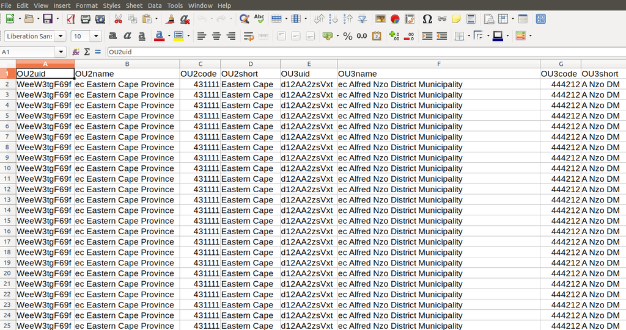

DoH Data Dictionary screenshot

### Tidy data

Data cleaning was performed in R (the code is included in [this document](https://github.com/anelda/merge_open_hospital_data/blob/master/reports/merge_open_hospital_data_part1.Rmd)).

| admin1_name | admin2_name | admin3_name | fac_id | fac_name | date_opened | date_closed | long | lat | phys_address | org_owner | org_rural_urban | type | admin1_abb |
| --- | --- | --- | --- | --- | --- | --- | --- | --- | --- | --- | --- | --- | --- |
| Eastern Cape | A Nzo | Matatiele | Fws0A9spb9F | Afsondering Clinic | 1994-01-01 | NA | 28.94812 | -30.1798 | Kwa Makhoba Location, Lusikisiki, 4820 | Gov Province | Rural | Clinic | EC |
| Eastern Cape | A Nzo | Matatiele | Wt1U8zI67lw | Bergview Pharmacy | 2018-07-01 | NA | 28.80539 | -30.3428 | Pick’n Pay Centre, Main Road, Matatiele | Private | Urban | Pharmacy | EC |
| Eastern Cape | A Nzo | Matatiele | aHIqh7chx7S | Dr Mpho Desmond Liphapang General Practitioner | 2014-03-01 | NA | NA | NA | NA | Private | Urban | General Practitioner | EC |
| Eastern Cape | A Nzo | Matatiele | oNIYza7bHm6 | Elukholweni Clinic | 1994-01-01 | NA | 28.84811 | -30.6329 | NA | Gov Province | Rural | Clinic | EC |
| Eastern Cape | A Nzo | Matatiele | f7IdRkIcJ5m | Isilindini Clinic | 1994-01-01 | NA | 28.59078 | -30.6200 | Zingcuka | Gov Province | Rural | Clinic | EC |
| Eastern Cape | A Nzo | Matatiele | SwOx9oIofK8 | Khotsong TB Hospital | 1994-01-01 | NA | 28.82118 | -30.3481 | Jagger Street | Gov Province | Urban | Specialised TB Hospital | EC |

## Healthsites.io

### Raw data format

The data was imported into R as a shapefile via the [`afrihealthsites` package](https://github.com/afrimapr/afrihealthsites) from [*afrimapr*](http://afrimapr.org).

### Tidy data

Data cleaning was performed in R (the code is included in [this document](https://github.com/anelda/merge_open_hospital_data/blob/master/reports/merge_open_hospital_data_part1.Rmd)).

| osm_id | osm_type | type | org_owner | water | num_surgeons_qual | contact_phone | electricity | open_hours | services | emergency | fac_name | num_nurses | wheelchair | num_beds_usable | web | dispensing | sector | country_name | country_iso3c | lat | long |
| --- | --- | --- | --- | --- | --- | --- | --- | --- | --- | --- | --- | --- | --- | --- | --- | --- | --- | --- | --- | --- | --- |
| 3309269515 | node | pharmacy |  |  | NA |  |  |  |  |  | Stellenbosch Square Pharmacy | NA |  | NA |  |  |  | South Africa | ZAF | 18.84201 | -33.97814 |
| 5657134129 | node | pharmacy |  |  | NA |  |  |  |  |  |  | NA |  | NA |  |  |  | South Africa | ZAF | 28.15224 | -26.16084 |
| 373386337 | node | pharmacy |  |  | NA |  |  |  |  |  | Link | NA |  | NA |  |  |  | South Africa | ZAF | 27.92697 | -26.10441 |
| 476903672 | way | hospital |  |  | NA |  |  |  |  |  | Maphutha Malatji Hospital | NA |  | NA |  |  |  | South Africa | ZAF | 31.03788 | -23.92632 |
| -3103077 | way | hospital |  |  | NA |  |  |  |  | yes | Milnerton Medi-Clinic | NA |  | NA |  |  |  | South Africa | ZAF | 18.50614 | -33.86543 |
| 292558722 | node | pharmacy |  |  | NA |  |  |  |  |  | Ringpharm | NA |  | NA |  |  |  | South Africa | ZAF | 28.26700 | -25.76763 |

### Addresses in healthsites.io

Very few of the health facilities have more information about where it is located i.e. province, district municipality, street address as can be seen in the table above. We therefore used reverse geocoding to go from coordinates (which was available in healthsites.io data) to addresses.

Using the `tmaptools` package in R to reverse geocode the coordinates, we were able to access a rich treasure trove of information including up to admin level 4 data, facility name, physical address, and more. Running the code took about 12 hours as we have to respect the fair usage policy of OSM. The R code is available in [this file](https://github.com/anelda/merge_open_hospital_data/blob/master/reports/merge_open_hospital_data_part1.Rmd).

| osm_id | osm_type | type | org_owner | water | num_surgeons_qual | contact_phone | electricity | open_hours | services | emergency | fac_name | num_nurses | wheelchair | num_beds_usable | web | dispensing | sector | country_name | country_iso3c | lat | long | phys_address | admin1_name | admin1_abb | admin2_name | admin3_name | admin4_name |
| --- | --- | --- | --- | --- | --- | --- | --- | --- | --- | --- | --- | --- | --- | --- | --- | --- | --- | --- | --- | --- | --- | --- | --- | --- | --- | --- | --- |
| 3309269515 | node | pharmacy |  |  | NA |  |  |  |  |  | Stellenbosch Square Pharmacy | NA |  | NA |  |  |  | South Africa | ZAF | 18.84201 | -33.97814 | NA, Webersvallei Road, NA, 7613 | Western Cape | WC | Cape Winelands | Stellenbosch | Stellenbosch Ward 21 |
| 5657134129 | node | pharmacy |  |  | NA |  |  |  |  |  |  | NA |  | NA |  |  |  | South Africa | ZAF | 28.15224 | -26.16084 | NA, Dunvegan Avenue, NA, 1609 | Gauteng | GP | City of Ekurhuleni | NA | Ekurhuleni Ward 19 |
| 373386337 | node | pharmacy |  |  | NA |  |  |  |  |  | Link | NA |  | NA |  |  |  | South Africa | ZAF | 27.92697 | -26.10441 | NA, Woodpecker Avenue, NA, 2169 | Gauteng | GP | City of Johannesburg | Roodepoort | Johannesburg Ward 126 |
| 476903672 | way | hospital |  |  | NA |  |  |  |  |  | Maphutha Malatji Hospital | NA |  | NA |  |  |  | South Africa | ZAF | 31.03788 | -23.92632 | NA, R71, NA, NA | Limpopo | LP | Mopani | NA | Ba-Phalaborwa Ward 3 |
| -3103077 | way | hospital |  |  | NA |  |  |  |  | yes | Milnerton Medi-Clinic | NA |  | NA |  |  |  | South Africa | ZAF | 18.50614 | -33.86543 | NA, Graaff Avenue, Milnerton, 2251 | Western Cape | WC | City of Cape Town | NA | Milnerton |
| 292558722 | node | pharmacy |  |  | NA |  |  |  |  |  | Ringpharm | NA |  | NA |  |  |  | South Africa | ZAF | 28.26700 | -25.76763 | NA, North Village Lane, NA, 0102 | Gauteng | GP | City of Tshwane | Pretoria | Tshwane Ward 82 |

## KEMRI/WHO

### Raw data

The data for the whole of sub-Saharan Africa was made available in an Excel spreadsheet. Health facility data is available from the sheet named ‘SSA MFL’. The data is also available from the [`afrihealthsites` package](http://afrimapr.org/code) that forms part of *[afrimapr](http://afrimapr.org)*. `afrihealthsites` offer two options for importing the data:

- sf format (Note that not all facilities listed in the raw data set have coordinates associated with them. Facilities without coordinates will not be available in the sf data object) and
- dataframe format (Including all facilities listed in the raw data file including those without coordinates).

[figure not shown]

KEMRI/WHO Raw Data

### Tidy data

Data cleaning was performed in R (the code is included in [this document](https://github.com/anelda/merge_open_hospital_data/blob/master/reports/merge_open_hospital_data_part1.Rmd)).

| country_name | admin1_name | fac_name | type | org_owner | lat | long | country_iso3c | admin1_abb |
| --- | --- | --- | --- | --- | --- | --- | --- | --- |
| South Africa | Eastern Cape | Aberdeen Hospital | District Hospital | MoH | -32.4862 | 24.06093 | ZAF | EC |
| South Africa | Eastern Cape | Aberdeen Satellite Clinic | Satellite Clinic | MoH | -32.4750 | 24.05200 | ZAF | EC |
| South Africa | Eastern Cape | AD Keet Clinic | Clinic | MoH | -34.0602 | 24.91831 | ZAF | EC |
| South Africa | Eastern Cape | Addo Clinic | Clinic | MoH | -33.5422 | 25.69077 | ZAF | EC |
| South Africa | Eastern Cape | Addo Enon Satellite Clinic | Satellite Clinic | MoH | -33.3946 | 25.54625 | ZAF | EC |
| South Africa | Eastern Cape | Adelaide Clinic | Clinic | MoH | -32.7071 | 26.29461 | ZAF | EC |

# What do we have?

## Further text cleaning in OpenRefine

There is a lot of weird things in the names of places, including municipality names, facility names, etc. OpenRefine is a great tool to look into what’s going on with names - especially if you want to manually inspect things before “fixing” them, rather than applying brute force operations on all elements in a column. We did some further cleaning up of the data set using this [JSON script](https://github.com/anelda/za_open_hospital_data/blob/master/scripts/tidy_mfl.json) in OpenRefine 3.2.

## Some statistics about the datasets

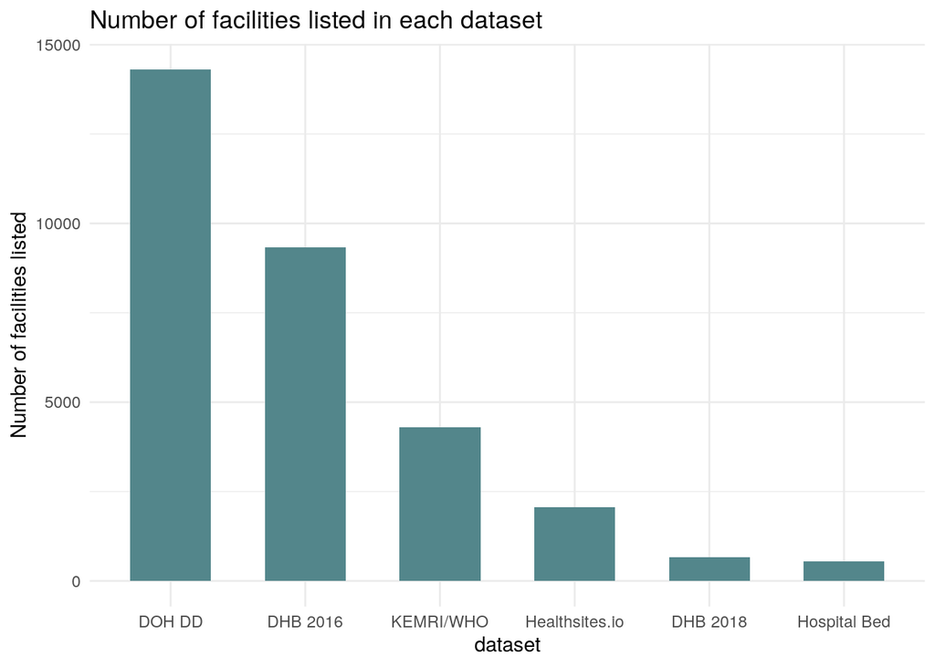

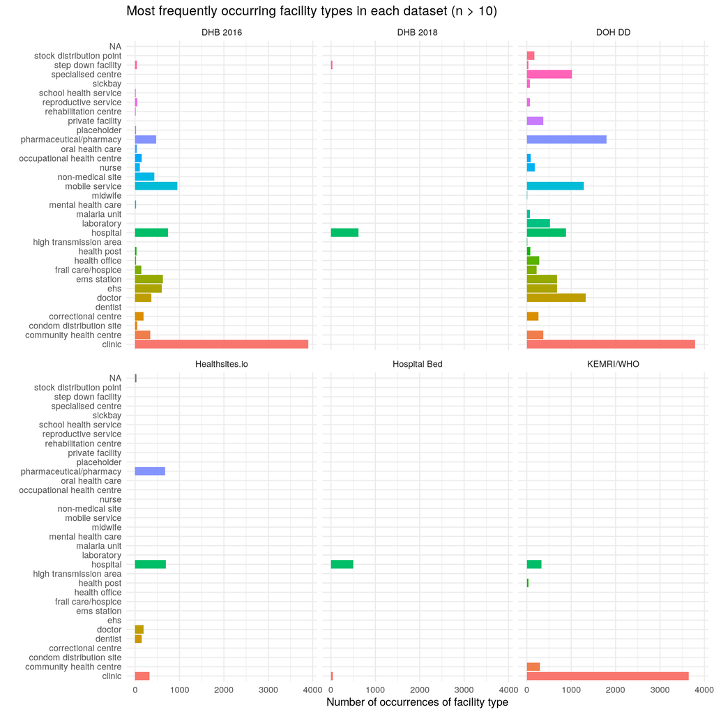

## Looking at completeness of the datasets

We counted the number of columns that are not empty (NA) and divided that total by the total number of columns(46) to calculate the percentage completeness per observation for each data set.

The table below shows the mean completeness for all the data sets. The most complete data set is healthsites.io, but we must point out that many of the master table columns were taken directly from the original healthsites.io column list and we have added information about various admin levels via reverse geocoding. It is clear that there is a *lot* of outstanding information in all datasets.

In the next step we’ll see if it is possible to add data from the various data sets together to get a more complete single entry for each health facility listed in the complete data set.

| dataset | Average completeness (%) |
| --- | --- |
| DHB 2016 | 20 |
| DHB 2018 | 27 |
| DOH DD | 33 |
| Healthsites.io | 56 |
| Hospital Bed | 33 |
| KEMRI/WHO | 22 |

## Combining information from different datasets

As we stated earlier on in the document, the ultimate goal of this project is to work through the process of collating the best possible facility list for South Africa by combining various openly available resources. We’re aiming to have a single entry for each facility from the total data set, with as much columns filled as possible.

It appears as if some of the data sets contain duplicates that differ only very slightly (almost indiscriminable). One example is *Ben-Chem Pharmacy* vs *Ben-Chem Dispensary Pharmacy* that also has slightly different coordinates in the two entries in a single data set. Another is the occurrence of *Clicks Mahikeng Pharmacy* vs *Clicks Mahikeng Mall Pharmacy* vs *Clicks Mahikeng Crossing Pharmacy* listed as three facilities in the DoH Data Dictionary even when two of these listings have exactly the same coordinates.

When we analyse facility names, it is important to note that some of the bigger chains (Dis-Chem, Clicks) may have several branches in a single city. At the same time some seemingly unique names may appear in more than one province. We can’t group by facility names only in trying to find the number of unique facilities in a data set.

Other factors that increases the difficulty of combining the data sets include:

- typos;
- varying capitalisation;
- different types of spelling (e.g. *KwaZulu Natal* vs *Kwa-Zulu Natal*);
- adding or dropping location information to facility names (when the location info isn’t officially part of the facility name e.g. *Clicks Mahikeng Pharmacy* which may be identified in one dataset as *Clicks* with location information specified in other columns);
- a single location being divided up into subsections (e.g. correctional health facility being divided up into maximum, medium or only showing correctional in different data sets);
- incorrect coordinates assigned to places may lead to incorrect reverse geocoding and interpretation of the different admin levels (e.g. *Bokomoso Pharmacy* vs *Bokamoso Health Pharmacy* is indicated to be in two different provinces, but Bokamoso is a specific area occurring only in one of the two provinces so clearly incorrectly geocoded in one of the data sets);
- incomplete names (e.g. *Boland (Touws River) Home Based Care* vs *Boland Hospice (Touws River) Home Based Care*);
- differences in naming conventions between data sets (e.g. *Booth Memorial Step Down Facility* vs *Booth Memorial Intermediate Care* and *Dora Nginza Dental Service* vs *Dora Nginza Oral Health Service*);
- name changes (e.g. *Sunshine Hospital* used to be *Actonville Hospital* also possibly *Gatesvill Medical Centre Private Hospital* as *Melomed Gatesville Hospital*);
- single facility occurring in the Healthsites data set with osm_type as both *way* and *node*;
- facilities may be listed as closed but may have undergone a name change or location change (e.g. *Cango Clinic Private Hospital*);
- not using full name of facility (e.g. *Albert Luthuli Local Municipality - LG EHS* vs *Chief Albert Luthuli Local Municipality - LG EHS*);
- incorrect entries (e.g. *Clicks Westgate Pharmacy Swartland* from DoH DD data set);
- generic names (e.g. *clinic* or *dental practice*);
- including translations in names (e.g. *Delmas Apteek Pharmacy* or having the name in non-English e.g. *Fouries Apteek* vs *Fouries Pharmacy*) and
- many more!

Clearly we should not be relying on the facility name, neither the coordinates to automatically combine information about locations that may appear to be the same place. And because of the variability in terms of completeness of the data, neither should we be grouping on too many administrative levels. The table below shows the frequency for a facility name within an area (up to admin level 4). More than 90% of the facilities are only observed once across the six data sets when we narrow the filter down to admin level 4. Visual inspection of the data set clearly shows a large number of “unique” observations are in fact duplicates across data sets and could be merged in a subsequent step.

The number times a specific facility name shows up across all datasets when we group by facility name and up to admin level 4

| # Observations | Count | Percentage |
| --- | --- | --- |
| 1 | 29339 | 94.04 |
| 2 - 5 | 905 | 2.90 |
| 6 - 10 | 2 | 0.01 |

When we only group the data based on facility name and admin level 1 the picture changes somewhat. The table below shows that a number of facilities are listed in the data sets without names. The more generic names (larger chain groups for example) are listed many times across several data sets and can only be separated into unique entries for merging if we also look at lower administrative level and descriptive data.

The number times a specific facility type shows up across all datasets when we group by facility name up to admin level 1

| Facility name | Admin level 1 | # Observations |
| --- | --- | --- |
| NA | GP | 111 |
| NA | WC | 72 |
| Clicks | GP | 69 |
| NA | KZ | 43 |
| Clicks | WC | 42 |
| Dis-Chem | GP | 31 |
| NA | EC | 28 |
| NA | NC | 28 |
| Clicks | EC | 17 |
| Clicks | KZ | 17 |

# Next steps

There is clearly a lot of work needed to clean up the data to get to a point where we can actually merge information related to individual facilities from different data sets.

Part two of this report will look further into data cleaning and options for merging of the various data sets. We’ve already started to investigate the possibility of using R packages such as [`fuzzyjoin`](https://cran.r-project.org/web/packages/fuzzyjoin/index.html) which implements, amongst other, the [`stringdist`](https://cran.r-project.org/web/packages/stringdist/index.html) package. `stringdist` can calculate string distances (i.e. the amount by which two character strings e.g. facility names differ) using a wide variety of algorithms.

We’re also exploring existing open source tools that allows one to merge facility lists, such as [Facility Match](https://www.facilitymatch.net/). Facility Match is an online tool developed by IntraHealth International with funding from PEPFAR and Digtal Square, the Bill & Melinda Gates Foundation, and a consortium of other investors. The tool is available under the open Apache License 2.0 and can be installed locally or used online.

There is no escape from physically inspecting the data and validating as much as possible before an attempt is made to merge the data, but we’d like to identiy the steps that can be automated and see how that can be implemented. So far we’ve relied on R and OpenRefine to do most of the cleanup, merging, and analysis. This workflow, if it can be streamlined, will be accessible in low income settings as both tools are available for free, under active development, and have good communities around it who can facilitate training and provide support.

# Acknowledgements

Thanks to [Andy South](https://twitter.com/southmapr) for reviewing the post and making suggestions about how to improve it.